# Lab-08

Author

Katie Zhao

## Learning Goals:

In this lab, you are expected to learn/put in practice the following skills:

- Evaluate whether a problem can be parallelized or not.
- Practice with the `parallel` package.

## **Problem 1: Vectorization**

The following functions can be written to be more efficient without using parallelization. Write a faster version of each function and show that (1) the outputs are the same as the slow version, and (2) your version is faster.

1. This function generates an `n x k` dataset with all its entries drawn from a Poission distribution with mean `lambda`.

```r
fun1 <- function(n = 100, k = 4, lambda = 4) {
  x <- NULL

  for (i in 1:n){
    x <- rbind(x, rpois(k, lambda))
  }

  return(x)
}


fun1alt <- function(n = 100, k = 4, lambda = 4) {

  matrix1 <- rpois(n*k, lambda)
  x <- matrix(matrix1, n, k)

  return(x)
}
```

Show that `fun1alt` generates a matrix with the same dimensions as `fun1` and that the values inside the two matrices follow similar distributions. Then check, using `microbenchmark::microbenchmark`, the speed of the two functions:

```r
library(tidyverse)
matrix1 <- fun1()
dim(matrix1)
```

```
[1] 100   4
```

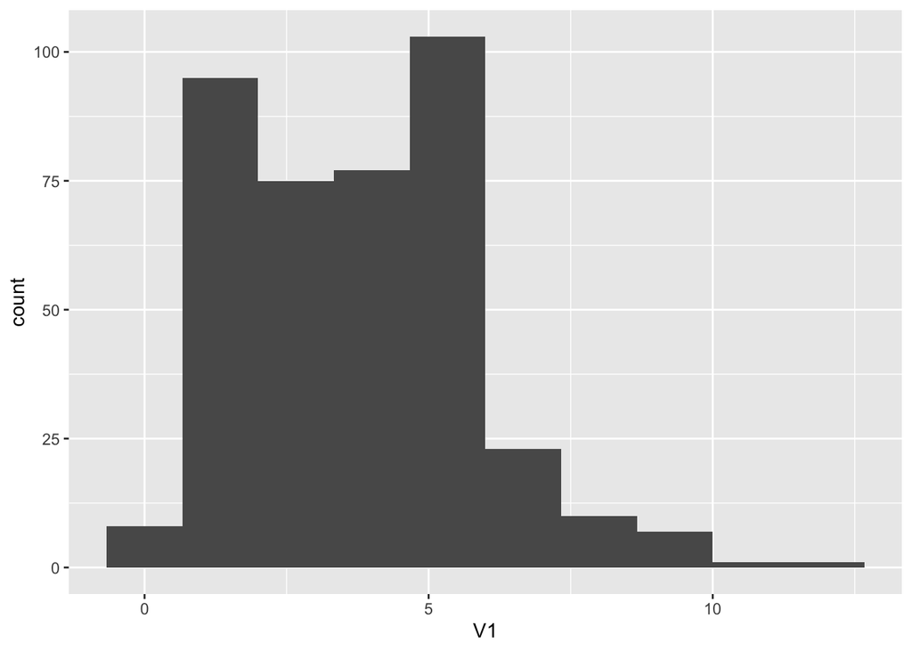

```r
matrix1 %>%
  matrix(nrow = 400, ncol = 1) %>%
  as.data.frame() %>%
  ggplot(aes(x = V1)) +
  geom_histogram(bins = 10)
```

```r
matrix1alt <- fun1alt()
dim(matrix1alt)
```

```
[1] 100   4
```

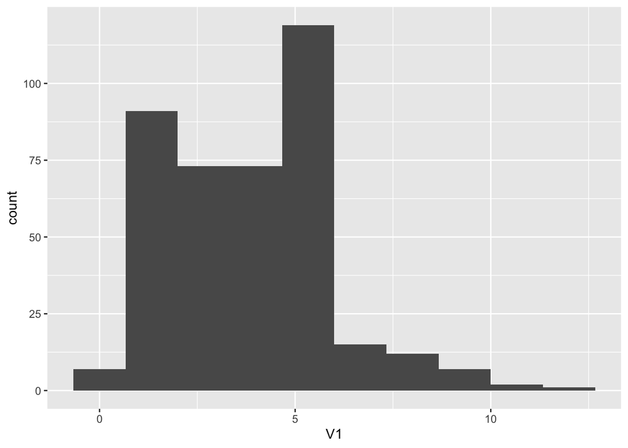

```r
matrix1alt %>%
  matrix(nrow = 400, ncol = 1) %>%
  as.data.frame() %>%
  ggplot(aes(x = V1)) +
  geom_histogram(bins = 10)
```

```r
# huh........ fix this
microbenchmark::microbenchmark(fun1(n = 100, k = 4, lambda = 4),
                               fun1alt(n = 100, k = 4, lambda = 4))
```

```
Unit: microseconds
                                expr    min      lq     mean median      uq
    fun1(n = 100, k = 4, lambda = 4) 79.622 81.8360 84.42146 82.902 85.2595
 fun1alt(n = 100, k = 4, lambda = 4)  8.077  8.5075 17.05846  8.733  8.9380
     max neval
 107.092   100
 835.990   100
```

2. This function finds the maximum value of each column of a matrix.

```r
# Data Generating Process (10 x 10,000 matrix)
set.seed(1234)
x <- matrix(rnorm(1e4), nrow=10)

# Find each column's max value
fun2 <- function(data) {
  apply(data, 2, max)
}

fun2alt <- function(data) {

  x <- NULL
  for(i in 1:ncol(data)) {
    x <- append(x, max(data[,i]))
  }
  return(x)

}
```

Show that both functions return the same output for a given input matrix, `x`. Then check the speed of the two functions, as you did above.

```r
set.seed(1234)
fun2(matrix(rnorm(1e4), nrow=10))
```

```
   [1]  1.08444118  2.41583518  0.57475572  1.10229755  1.44949627  1.64781747
   [7]  2.54899107  2.07027086  0.85023226  2.12111711  0.41452353  0.84927420
  [13]  2.05816199  1.01369035  1.66285645  1.63874465  1.67820574  3.04376589
  [19]  1.98373220  2.16803254  1.84246363  1.49349310  2.91914013  0.59427377
  [25]  1.35727444  1.47696959  0.97580332  2.04940300  0.81368286  1.80980539
  [31]  1.61439150  1.54998338  1.12648273  1.61978988  1.16457525  1.94871306
  [37]  2.25184180  0.50083593  1.45418687  1.59722809  1.46328305  1.13301019
  [43]  1.58515916  1.63559945  2.06248097  1.79706243  0.69797519  1.41009405
  [49]  3.19590120  2.23938817  1.78260790  1.30919086  1.46672264  1.63534746
  [55]  1.30347768  0.95382348  1.39009510  0.44450337  1.15442128  0.92726540
  [61]  1.47939487  1.53966324  1.72255181  1.46026575  0.29498789  0.97002419
  [67]  1.62729134  0.99750992  0.93781114  2.15370722  1.42542069  1.75544951
  [73]  0.88003799  1.37414476  2.34596566  1.20848488  1.62289758  2.70577505
  [79]  1.61224179  1.15657044  1.81096073  2.35781739  1.40659549  2.24975552
  [85]  0.89700619  1.39905531  1.45144363  1.20276705  1.79220701  1.48709810
```

[output cut: 152 more lines]

```r
set.seed(1234)
fun2alt(matrix(rnorm(1e4), nrow=10))
```

```
   [1]  1.08444118  2.41583518  0.57475572  1.10229755  1.44949627  1.64781747
   [7]  2.54899107  2.07027086  0.85023226  2.12111711  0.41452353  0.84927420
  [13]  2.05816199  1.01369035  1.66285645  1.63874465  1.67820574  3.04376589
  [19]  1.98373220  2.16803254  1.84246363  1.49349310  2.91914013  0.59427377
  [25]  1.35727444  1.47696959  0.97580332  2.04940300  0.81368286  1.80980539
  [31]  1.61439150  1.54998338  1.12648273  1.61978988  1.16457525  1.94871306
  [37]  2.25184180  0.50083593  1.45418687  1.59722809  1.46328305  1.13301019
  [43]  1.58515916  1.63559945  2.06248097  1.79706243  0.69797519  1.41009405
  [49]  3.19590120  2.23938817  1.78260790  1.30919086  1.46672264  1.63534746
  [55]  1.30347768  0.95382348  1.39009510  0.44450337  1.15442128  0.92726540
  [61]  1.47939487  1.53966324  1.72255181  1.46026575  0.29498789  0.97002419
  [67]  1.62729134  0.99750992  0.93781114  2.15370722  1.42542069  1.75544951
  [73]  0.88003799  1.37414476  2.34596566  1.20848488  1.62289758  2.70577505
  [79]  1.61224179  1.15657044  1.81096073  2.35781739  1.40659549  2.24975552
  [85]  0.89700619  1.39905531  1.45144363  1.20276705  1.79220701  1.48709810
```

[output cut: 152 more lines]

```r
microbenchmark::microbenchmark(fun2(matrix(rnorm(1e4), nrow=10)),
                               fun2alt(matrix(rnorm(1e4), nrow=10)))
```

```
Unit: microseconds
                                     expr      min        lq      mean   median
    fun2(matrix(rnorm(10000), nrow = 10))  483.390  503.1725  522.8172  515.370
 fun2alt(matrix(rnorm(10000), nrow = 10)) 1130.493 1251.4635 1488.8084 1318.396
       uq      max neval
  532.344  964.812   100
 1371.122 4789.538   100
```

## **Problem 2: Parallelization**

We will now turn our attention to the statistical concept of bootstrapping. Among its many uses, non-parametric bootstrapping allows us to obtain confidence intervals for parameter estimates without relying on parametric assumptions. Don’t worry if these concepts are unfamiliar, we only care about the computation methods in this lab, not the statistics.

The main assumption is that we can approximate the results of many repeated experiments by resampling observations from our original dataset, which reflects the population.

1. This function implements a serial version of the bootstrap. Edit this function to parallelize the `lapply` loop, using whichever method you prefer. Rather than specifying the number of cores to use, use the number given by the `ncpus` argument, so that we can test it with different numbers of cores later.

```r
library(parallel)

my_boot <- function(dat, stat, R, ncpus = 1L) {

  # Getting the random indices
  n <- nrow(dat)
  idx <- matrix(sample.int(n, n*R, TRUE), nrow=n, ncol=R)

  # THIS FUNCTION NEEDS TO BE PARALELLIZED

  cl <- makeCluster(ncpus)
  clusterExport(cl, c("dat", "stat"), envir = environment())

  ans <- parLapply(
    cl = cl,
    X = seq_len(R),
    fun = function(i) {
      stat(dat[idx[,i], , drop=FALSE])
      })

  # Converting the list into a matrix
  ans <- do.call(rbind, ans)

  return(ans)
}
```

2. Once you have a version of the `my_boot()` function that runs on multiple cores, check that it provides accurate results by comparing it to a parametric model:

```r
# Bootstrap of an OLS
my_stat <- function(d) coef(lm(y ~ x, data=d))

# DATA SIM
set.seed(1)
n <- 500; R <- 1e4

x <- cbind(rnorm(n)); y <- x*5 + rnorm(n)

# Checking if we get something similar as lm
ans0 <- confint(lm(y~x))
ans1 <- my_boot(dat = data.frame(x, y), my_stat, R = R, ncpus = 2L)

# You should get something like this
t(apply(ans1, 2, quantile, c(.025,.975)))
```

```
                  2.5%      97.5%
(Intercept) -0.1386903 0.04856752
x            4.8685162 5.04351239
```

```r
##                   2.5%      97.5%
## (Intercept) -0.1372435 0.05074397
## x            4.8680977 5.04539763
ans0
```

```
                 2.5 %     97.5 %
(Intercept) -0.1379033 0.04797344
x            4.8650100 5.04883353
```

```r
##                  2.5 %     97.5 %
## (Intercept) -0.1379033 0.04797344
## x            4.8650100 5.04883353
```

3. Check whether your version actually goes faster when it’s run on multiple cores (since this might take a little while to run, we’ll use `system.time` and just run each version once, rather than `microbenchmark`, which would run each version 100 times, by default):

```r
system.time(my_boot(dat = data.frame(x, y), my_stat, R = R, ncpus = 1L))
```

```
   user  system elapsed
  0.042   0.011   2.028
```

```r
system.time(my_boot(dat = data.frame(x, y), my_stat, R = R, ncpus = 3L))
```

```
   user  system elapsed
  0.061   0.027   0.912
```

## **Problem 3: Short answer**

1. **Explain in your own words how you can decide if a problem is fit for parallelization?**

A problem is suitable for parallelization if it requires a task to be run many times, and where running differents “parts” of the problem does not require information/data from a different upstream sequential part of the problem (or, there is no sequential nature to the problem such that separating the computation to different nodes would leave the system unable to compute an answer).

2. **We have covered vectorization and parallelization in this lab. Explain in your own words how you can think about the relationship between vectorization and paralleization? How do we know whether we should use one or the other or both?**

**Vectorization:** Inherent to a data structure, where the same computation to be applied to every element / set of elements in the data. Instead of needing to directly run a “for loop” to perform the same operation on every data point, can use vectorization instead (vectorization can be described as a type of parallelization).

**Parallelization:** An efficient computation method to speed-up the process of computation by using multiple “computers systems/nodes” to distribute tasks to solve the problem in parallel.